# Introduction

For this project, we will combine our efforts to analyze the film industry across time. Our passion for movies has made us question the decrease in the production of some of our favorite movie genres in the last few years. We will try to find out if the following analysis can take us on the right path to discover some of the variables that are shaping the production trend in the film industry.

# Background Information

After the invention of the kinetoscope in 1891, film inventors have done their best to come up with new ways to innovate the film industry. Over time, the film industry has passed through different eras going from silent movies to 3D animations. However, in the last years, producers now seem to be focusing more on the production of some specific genres. A visit to a movie theater can confirm that there are some genres like romance and drama that are less common compared to horror, animation, and action movies.

Hollywood produces more than 700 movies on average every year. The main film distributors are Disney, Universal, Paramount, Warner Bros, MGM, and Sony. Hollywood is the most influential and oldest film industry, followed by India (Bollywood), China, United Kingdom, and Japan.While China has become the largest box office territory, The US still has the largest box office from national films and still dominates The Oscars.In terms of productions, Indian is on top of the chart with almost 2000 films yearly.

We believe that the information above is crucial to narrow down our following analysis.

## Goal of This Tutorial

The goal of this tutorial is to provide a sample Data Science project that walks through the Data Science pipeline. The Data Science pipeline consists of five main stages: Data Collection, Data Processing, Exploratory Analysis, Hypothesis Testing, and Insight & Policy Decision. The order that a researcher proceeds through the fours stages is typically non-linear. This is because as a researcher progress through the pipeline, they might find it necceasry to revisit stages that they have already done. For instance, while at the Hypothesis Testing stage you determined that inorder to accuratly test your hypthesis you would need data is a certain format. Unfortunately, that data is in a different format. That would cause you to jump from the Hypothesis Testing and back to the Data Proccessing stage.

- Data Collection: The action of gathering the data
- Data proccessing: The act of gathering the data that you are interested in analyazing and getting it in the required format for your system/platform
- Exploratory Analysis: Exploring the data and seeing what it looks like through various visuals
- Analysis, Hypothesis, Testing, and Machine Learning: Doing actaul analysis to test the idea gained in the exploratory stage
- Insight & Policy Decision: Communicating what has been donw and why is important

At the end of this tutorial we hope that the reader better understands the phases that are implemented in Data Science projects, the background descisions and thought process that are involved, and the fact that Data Science is really subjective - most of the time there is no one size fits all implementation/solution!

#### General Data Topics We Were Interested Analyzing in the Project

- How does amovie's genre related to its total gross/yearly gross?
- Does the rating correlate to the movie gross?
- What about the number of box office releases for that movie?
- If the movie with year's highest movie gross is of a specific genre to are more movies of that genre produced?
- Is there any relation the genre of movies being released and the average movie gross for the genre?
- Is there any relation to genre and movie gross in general?

#### Things to Keep in Mind

- We, the group we created this tutorial, had a limited amount of time (roughly two weeks) that we could dedicate towards creating this tutorial. Due to that time constaint, and the large amount of effort getting/formatting the data took, a large potion of the tutorial will be dedicated to the Data Processing stage.
- That time constraint also made it impossible to proccess all the data we have available at our fingertips - meaning in the data we recieved on the internet. We had to figure out a way to reduce the ammount of data we analyze so this tutorial would be done in time. As a result, we decided to only look at movie data from 1960's and onwards. We picked the 1960's because the 1960's is commonly agreed as the start of the Hollywood era. Since our general question center arount veiwer ratings and box office movie gross, its more likely that we would get more accurate data using the 1960 and later data.

## Gathering Data

Publically available data containing movie/tv shows genres, rating, year gross, and year of release has already been collected by various reputable sources. We chose to investigate the IMDb Datasets (https://www.imdb.com/interfaces/) and the BoxOfficeMojo Domestic Yearly Box Office dataset (https://www.boxofficemojo.com/year/?grossesOption=calendarGrosses). These datasets have movie data going back all the way to 1874. The datasets also contain a wide range of potentially interesting data including: if it's an Adult movie, the production year, other(potentially foriegn) titles,names of directors, names of writers, etc. Another big positive to working with these datasets is that they are completely free to the public.

Meanwhile with other media datasets, while they are just as extensive as IMDb, they would require a payment to get the complete dataset and not just a sample. For instance, another database we were considering using was The Numbers (https://www.the-numbers.com/box-office-records/domestic/all-movies/cumulative/all-time/2501). However, we realised to get the data we required we would have to pay $475.

## Data Processing

There times when the data you recieve from the databases are not in the correct format. Or, in a format that is difficult for the system to comprehend/handle.

We will be using three datasets from IMDb. We must use three datasets instead of one since each dataset has relevant data to our question. However, there isn't one already made dataset that has all the information. As a result, we must upload all three databases, get the relevant infomation for each, and then combine the relavent data into one dataframe.

As mentioned in the Gathering Data section, one positive to IMDb Datasaets is that we would have a large dataset to analyze and explore. However, it is also a negative. Because it is so large (a total of 710 MB!!), it is impossible for most laptops/computers to process the data all at once. As a result, it must be condensed to only contain data we think may be relavent in future analysis and must be proccessed in chunks.

NOTE: This is a common problem in data science and would most likely need to be addressed when you do data science analysis in the future.

#### Getting the IMDb DataFrames

```python
import pandas as pd
import requests as rq
from bs4 import BeautifulSoup

#dictates the number of rows each data frame should have
chunksize = 100000

# the list that contains all the dataframes
list_of_dataframes = []


# Seperates title.basics.tsv into chunks with 100000 rows with the header of row 0.
#The columns of the dataframes would be tconst, originalTitle, startYear (publication year),
#and genres data. each chunck is added to list_of_dataframes
for df in pd.read_csv("title.basics.tsv", sep='\t', chunksize=chunksize,
                       header=0, usecols=['tconst', 'primaryTitle', 'genres', 'startYear', 'endYear']):
      list_of_dataframes.append(df)

#concats all the chunck dataframes to make one combined
data1 = pd.concat(list_of_dataframes)




#Seperates title.basics.tsv into chunks with 100000 rows with the header of row 0.
#The columns of the dataframes would be tconst, originalTitle, startYear (publication year),
#and genres data. each chunck is added to list_of_dataframes
for df in pd.read_csv("title.basics.tsv", sep='\t', chunksize=chunksize,
                       header=0, usecols=['tconst', 'primaryTitle', 'genres', 'startYear', 'endYear']):
      list_of_dataframes.append(df)

#concats all the chunck dataframes to make one combined
data1 = pd.concat(list_of_dataframes)
```

```python
data1.head()
```

|  | tconst | primaryTitle | startYear | endYear | genres |
| --- | --- | --- | --- | --- | --- |
| 0 | tt0000001 | Carmencita | 1894 | \N | Documentary,Short |
| 1 | tt0000002 | Le clown et ses chiens | 1892 | \N | Animation,Short |
| 2 | tt0000003 | Pauvre Pierrot | 1892 | \N | Animation,Comedy,Romance |
| 3 | tt0000004 | Un bon bock | 1892 | \N | Animation,Short |
| 4 | tt0000005 | Blacksmith Scene | 1893 | \N | Comedy,Short |

Each production instance/row has the following features/attributes:

- tconst - IMDb's alphanumeric unique identifier of the movie title
- primaryTitle – the more popular movie title / the movietitle used by the filmmakers on promotional materials at the point of release
- startYear – represents the release year of a movie title. In the case of TV Series, it is the series start year
- endYear – TV Series end year. ‘\N’ for all other title types
- genres – includes up to three genres associated with the title

All of them are object types.

```python
#makes a dataframe from the data in the title.ratings.tsv database
#averageRating is the average IMDb rating , numVotes is the number of IMDd
#votes the movie recieved
data2= pd.read_csv("title.ratings.tsv", sep='\t')
data2.head()
```

|  | tconst | averageRating | numVotes |
| --- | --- | --- | --- |
| 0 | tt0000001 | 5.7 | 1718 |
| 1 | tt0000002 | 6.0 | 211 |
| 2 | tt0000003 | 6.5 | 1480 |
| 3 | tt0000004 | 6.1 | 124 |
| 4 | tt0000005 | 6.2 | 2283 |

Each movie instance/row has the following features/attributes:

- tconst - IMDb's alphanumeric unique identifier of the movie title (same as dataframe above)
- averageRating – weighted average of all the individual user ratings
- numVotes - number of votes the title has received

```python
#makes a dataframe from a portion of data in the data.tsv database
#it only collects the columns of titleID and region and puts that in a dataframe
data3= pd.read_csv("data.tsv", sep='\t', usecols=['titleId', 'region'])

# gets all the rows with the region being US
data3 = data3[data3['region'] == 'US']

#removes the region column since it is no longer needed
data3=data3.drop(columns=['region'])

data3.head()
```

|  | titleId |
| --- | --- |
| 5 | tt0000001 |
| 14 | tt0000002 |
| 35 | tt0000005 |
| 39 | tt0000005 |
| 40 | tt0000005 |

Each movie instance/row has the following features/attributes:

- titleID (object) - IMDb's alphanumeric unique identifier of the movie title (same as dataframe above)

#### Combining the IMDb DataFrames

When combining DataFrames, or any type of table, you will have to decide how the join should occur and how that should relate to missing data. Let's say that you have two tables/DataFrames. Table 1 has Data1 values and Table 2 has Data2 value. We will be discussing three main ways to approach merging the two data sets:

- Inner Join: Only the rows that are shared acorrding to your defintion (ie. column value, index, etc) between the two tables are put into the new table. That means that there will be no missing data in the final DataFrame/Table since each row will have both Data1 and Data2 values.
- Left Join: It provides the same results as Inner Join but it would also include rows that have Data1 values (when considering Table 1 as the left table-which can also be described as the base table) but no Data 2 values. In this case there will be missing data.
- Right Join: It provides the same results as Inner Join but it would also include rows that have Data2 values (when considering Table 2 as the right table-the table that is being merged in) but no Data1 values. In this case there will be missing data.

Below, you will see that we choose to inner join when merging the IMDb Dataframes. That is because for our research we only wanted the movie data that has all the data since we will explore how those data relate to each other. If a value was missing then using that missing data can lead to future compuutaion errors and confusion.

NOTE: There is definitive join that should always be used. You must consider what you are trying to achieve with that data and the releavance of the missing data when determining which join to use.

```python
#merges (through inner join) data1 and data2 based on the tconst values
#and makes it a dataframe named partial_data_table
partial_table= pd.merge(data1, data2, on='tconst')
partial_table.head()
```

|  | tconst | primaryTitle | startYear | endYear | genres | averageRating | numVotes |
| --- | --- | --- | --- | --- | --- | --- | --- |
| 0 | tt0000001 | Carmencita | 1894 | \N | Documentary,Short | 5.7 | 1718 |
| 1 | tt0000001 | Carmencita | 1894 | \N | Documentary,Short | 5.7 | 1718 |
| 2 | tt0000002 | Le clown et ses chiens | 1892 | \N | Animation,Short | 6.0 | 211 |
| 3 | tt0000002 | Le clown et ses chiens | 1892 | \N | Animation,Short | 6.0 | 211 |
| 4 | tt0000003 | Pauvre Pierrot | 1892 | \N | Animation,Comedy,Romance | 6.5 | 1480 |

```python
#filters partial_data_table based on weither the row's title constant can be found in data3
#Full_table has all the information (title, genres, averateRating, etc) for only the US productions
full_table=partial_table.loc[partial_table["tconst"].isin(data3["titleId"])]
full_table.head()
```

|  | tconst | primaryTitle | startYear | endYear | genres | averageRating | numVotes |
| --- | --- | --- | --- | --- | --- | --- | --- |
| 0 | tt0000001 | Carmencita | 1894 | \N | Documentary,Short | 5.7 | 1718 |
| 1 | tt0000001 | Carmencita | 1894 | \N | Documentary,Short | 5.7 | 1718 |
| 2 | tt0000002 | Le clown et ses chiens | 1892 | \N | Animation,Short | 6.0 | 211 |
| 3 | tt0000002 | Le clown et ses chiens | 1892 | \N | Animation,Short | 6.0 | 211 |
| 8 | tt0000005 | Blacksmith Scene | 1893 | \N | Comedy,Short | 6.2 | 2283 |

#### Getting the BoxOfficeMojo DataFrame

One nice part about the IMDb data is that it has an API that makes retreiving the movie data and converting it to the correct format (for this tutorial that would be Pandas DataFrames) very straight forward. As you see above, we can download the file directly and then read it in to a Datafreame. However, not all website has that capability. For instance, the BoxOfficeMojo Domestic Yearly Box Office dataset does not API. As a result, we will have to use a technique called Data Scraping.

DataScraping is when we must get the all contents of the website, select the sections that we want to put into a DataFrame, clean up that section if needed so it fits the format of a Datframe, and then we can convert it to a DataFrame. In this instance, the desired section would be the the table containing the Domestic Yearly Box Office dataset.

```python
source = rq.get('https://www.boxofficemojo.com/year/?grossesOption=calendarGrosses&sort=year&ref_=bo_yl__resort#table')

#gets the structure out of the html text (in form of string)
soup = BeautifulSoup(source.text)

#prints a more human readable version of the soup variable/reading it as HTML
#prints the html formated by BeautifulSoup
print(soup.prettify())
```

[output not shown]

[output cut: 1430 more lines]

```python
#gets the first instance of a table in the BeautifulSoup type since noticed in prettify
#that the first table has the desired data
table = soup.find('table')

#panda reads the table (which is concerted into a string first) and displays the
#first, and only, table in the dataframe.
movie_gross= pd.read_html(table.prettify())[0]

#renames two of the columns to more appropriate names
movie_gross=movie_gross.rename(columns={"Average": "AverageGrossPerRelease",
                                     "Releases":"NumberOfReleases" })

#removes the %± LY column since we do not care aout the gross change per year
movie_gross=movie_gross.drop(columns=["%± LY"])
movie_gross.head()
```

|  | Year | Total Gross | NumberOfReleases | AverageGrossPerRelease | #1 Release |
| --- | --- | --- | --- | --- | --- |
| 0 | 2021 | $1,404,521,878 | 230 | $6,106,616 | A Quiet Place Part II |
| 1 | 2020 | $2,103,085,767 | 455 | $4,622,166 | Bad Boys for Life |
| 2 | 2019 | $11,320,878,436 | 911 | $12,426,869 | Avengers: Endgame |
| 3 | 2018 | $11,889,341,443 | 993 | $11,973,153 | Black Panther |
| 4 | 2017 | $11,072,815,067 | 852 | $12,996,261 | Star Wars: Episode VIII - The Last Jedi |

#### Processing Unavailable Data in the DataFrames

It is very important the data within the dataframe that is unavailable is categorized properly and uniformly.

There is no uniform rule on how different databases will represent missing data. Some databases put '-', others write 'NONE', or an empty string. There is an infinite amount of possibilities that databases could use. However, what is important from the data science perspective is how will Pandas interpret those values and having a concesus within the community.

Inorder to Pandas (and the community) to understand that a value is missing, that cell must have one of these values:

numpy.NaN (numpy): A number value is not available in a number column numpy.nan (numpy): Same as the above (either one could be use for a missing number) pd.NaT (pandas):A time value in a time column is not available pd.NA (pandas): A general type of value is Not Available None (python): similar to pd.NA Note: Data has an underlying meaning. If something was meant to be number but turned out not to be, that could be potentially different from it not being available.

According to the IMBd website, their databases use ‘\N’ to denote that a particular field is missing or null for that title/name. These must be converted to an appropriate value from the list above. When looking over the BoxOfficeMojo data manually we can see that there is is no missing data. However, it is always best to do checks just in incase.

```python
import numpy

#replaces all instance of missing values in the full_table
#dataframe as replace it with a pd Null or numpy Null value
full_table['primaryTitle'].replace({'\\N': pd.NA}, inplace=True)
full_table['genres'].replace({'\\N': pd.NA}, inplace=True)
full_table['startYear'].replace({'\\N': pd.NaT}, inplace=True)
full_table['endYear'].replace({'\\N': pd.NaT}, inplace=True)
full_table['averageRating'].replace({'\\N':numpy.NaN}, inplace=True)
full_table['numVotes'].replace({'\\N':numpy.NaN}, inplace=True)
```

```python
#gets the rows where the endYear is a null value
full_table=full_table[full_table['endYear'].isna()]

#removes the endYear column since it is no longer needed
full_table=full_table.drop(columns=['endYear'])

#renames two of the columns to more appropriate names
full_table=full_table.rename(columns={"primaryTitle": "title", "startYear": "releaseYear"})

full_table.head()
```

|  | tconst | title | releaseYear | genres | averageRating | numVotes |
| --- | --- | --- | --- | --- | --- | --- |
| 0 | tt0000001 | Carmencita | 1894 | Documentary,Short | 5.7 | 1718 |
| 1 | tt0000001 | Carmencita | 1894 | Documentary,Short | 5.7 | 1718 |
| 2 | tt0000002 | Le clown et ses chiens | 1892 | Animation,Short | 6.0 | 211 |
| 3 | tt0000002 | Le clown et ses chiens | 1892 | Animation,Short | 6.0 | 211 |
| 8 | tt0000005 | Blacksmith Scene | 1893 | Comedy,Short | 6.2 | 2283 |

We are removing the rows that don't have a null value in the endYear column because, as noted on the IMDb api website, when an endYear is provided that means it is a tv series. Not a movie. Since we only care about movies, the information about TV series are irrevalant and should be delected to prevent possible future errors

#### Converting the types of the columns

Inorder to the graphing and analysis it is important that data are in the 'correct' type. By 'correct', we mean a type that makes sense according to what the data represents and according the expectation of other Data Scientist/evaluators/contributers to your work.

Now what is a type in Data Science? It is definatelly not the same thing as a type (int, float, string, etc) in a general computer science. A type in Data Science is divided into 2 main categories (Categorical and Numeric) and 4 sub categories:

- Nominal(Categorical): This is abstract categorical data and is a finite set (ie 5 soda flavors, marital status). There is no way to compare between Nominal data type and thus there is no order to the set (you can't say scientifically that one is 'better'/'greater' than the other). One can say that you can order anything and that is true! But we define if we can order it or not depending on if the ordering would have meaning where how/why the data is used is being considered. Ordering nominal data would have no meaning.
- Ordinal(Categorical): It is like Nominal but now the items in the set can be put in sometype of meaningful order. One example would the days of of one week. Since the duration of the data is during one week we can say the the data of Tuesday is before Wednesday, Saturday is after Friday and so on. But if was on a span of multiple weeks then that would not be possible. Another example would be rating a teacher boring, neutral, or exciting. Although now there is an order to the data there is no mathmatical way of measuring the distance bewteeen the categories.
- Interval(Numeric): Now the data is like Oridinal since it has ordering but it also has a way of measuring distance b etween the ctaegories. Two examples are grade levels or temperature. However theis data doesn;t make sense in terms of fractions/ratios (imagine in being in grade3/grade5!)
- Ratio(Numeric): It is similar to Interval Data but now ratios between the values are meaningful and there is a meaningful zero value. You can think of it as categorical data with order, distcance, and ratiios. Some examples would be ttear ratings in stars and measurements in miles.

Using those decsriptions you will be able to determine which type (now using the general Computer Science definition) should the data be. Originally most of the data we got were in the type Object-which is best for categorial data. However, by looking at the data we knew that select columns should be Ratio or Interval data types instead (int, floats, long, etc). If we kept them as objects that would have lead to major conusion later on in the pipeline.

```python
#converts the releaseYear, numVotes to int types and  averageRating to float type
full_table["releaseYear"] = full_table["releaseYear"].astype(int)
full_table ["averageRating"] = full_table["averageRating"].astype(float)
full_table ["numVotes"] = full_table["numVotes"].astype(int)

#sorts the table in descending order occrding to the release Year
full_table = full_table.sort_values(by=['releaseYear'], ascending=False)

full_table.head()
```

|  | tconst | title | releaseYear | genres | averageRating | numVotes |
| --- | --- | --- | --- | --- | --- | --- |
| 1159570 | tt13026416 | Super Mario 3D World + Bowser's Fury | 2021 | Action,Adventure,Fantasy | 8.8 | 185 |
| 1286894 | tt14871658 | UFC 263: Adesanya vs. Vettori 2 | 2021 | Sport | 6.7 | 12 |
| 1287851 | tt14893986 | The Last of Us: Ellie's Revenge | 2021 | Action,Short | 8.8 | 6 |
| 1287850 | tt14893986 | The Last of Us: Ellie's Revenge | 2021 | Action,Short | 8.8 | 6 |
| 1190930 | tt13404978 | Head of the Snake | 2021 | Action,Crime,Drama | 8.8 | 299 |

Each column now has the following type:

- tconst - object
- title- object
- releaseYear - int
- genres - object
- averageRating - float
- numVotes - int

```python
#converts the Year, Total Gross, NumberOfReleases, and AverageGrossPerRelease to int types
movie_gross["NumberOfReleases"]= movie_gross["NumberOfReleases"].astype(int)
movie_gross["Year"]= movie_gross["Year"].astype(int)
movie_gross["Total Gross"]= [int(x[1:].replace(",", "")) if pd.notnull(x) else x for x in movie_gross["Total Gross"]]
movie_gross["AverageGrossPerRelease"]= [int(x[1:].replace(",", "")) if pd.notnull(x) else x for x in movie_gross["AverageGrossPerRelease"]]

#sorts the table in descending order occrding to the Year
movie_gross = movie_gross.sort_values(by=['Year'], ascending=False)
movie_gross.head()
```

|  | Year | Total Gross | NumberOfReleases | AverageGrossPerRelease | #1 Release |
| --- | --- | --- | --- | --- | --- |
| 0 | 2021 | 1404521878 | 230 | 6106616 | A Quiet Place Part II |
| 1 | 2020 | 2103085767 | 455 | 4622166 | Bad Boys for Life |
| 2 | 2019 | 11320878436 | 911 | 12426869 | Avengers: Endgame |
| 3 | 2018 | 11889341443 | 993 | 11973153 | Black Panther |
| 4 | 2017 | 11072815067 | 852 | 12996261 | Star Wars: Episode VIII - The Last Jedi |

Each column now has the following type:

- Year - int
- Total Gross - int
- NumberOfReleases - int
- AverageGrossPerRelease - int
- #1 Release - Object

#### Reducing the data to 1960 and later

As stated earlier, it was neccesary for us to restrict the data to 1960 and later due to time constrants. If given more time then it might have been benefical to explore the entire data set or even compare between the movie eras.

```python
#removes the rows from both dataframes that have a releaseYear/Year value later then 1960
full_table = full_table[full_table["releaseYear"] >1959]
movie_gross = movie_gross[movie_gross["Year"] >1959]
```

## Exploratory Anaylsis and Data Visualization

As mentioned earlier, the Exploratory Analysis and Data Visualization phase is centered around exploring the data, seeing what looks interesting, and getting a better understanding of what should be futther looked into. This also allows the Data Scientist to try and see if there are any patterns within the data. Inorder to do that, this phase ususally invvles a lot of visualizations since the human brain is very grood at detecting patterns. There should not be any conclusions within this stage, only seeing what should be explored further on in the pipeline.

Below you will see some of the exploratory paths we took with the movie data when in this stage of the pipeline.

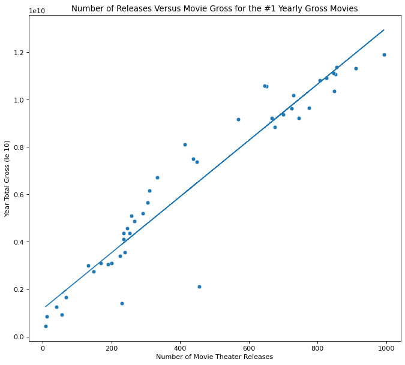

```python
import numpy as np
plt.rcParams.update({'font.size': 10}) #sets size of labels/title
figure(figsize=(10, 9), dpi=80)#sets the figure/graph size

#creates scatterplot with year data (from data dataframe) as x values and
#lifeExp data (from data dataframe) as y values
ax=sns.scatterplot(x='NumberOfReleases', y='Total Gross', data=temp)

plt.xlabel('Number of Movie Theater Releases') #y label
plt.ylabel('Year Total Gross (le 10)')#x label
plt.title("Number of Releases Versus Movie Gross for the #1 Yearly Gross Movies") #makes title

# uses the x and y columns....
x= temp['NumberOfReleases']
y= temp['Total Gross']

# ...to get the m and b for the line of best fit (degree of 1)
#plots that line on the graph
m, b = np.polyfit(x,y,1)
plt.plot(x, m*x+b)

plt.show()
```

Lets take a look at the total amount of film productions by genre across time. Approaching this analysis is quite challenging because the genre column in our dataframe does not contain a single genre value. Most movies listed in the data are listed under at least two different genres, therefore, we have decided to count the movies for as many genres they are listed for.

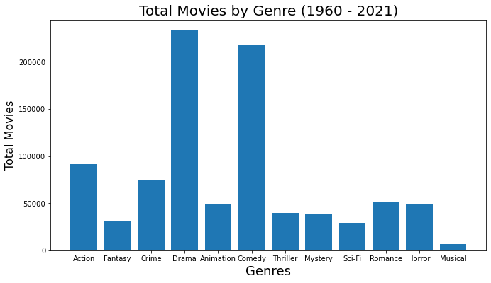

```python
from collections import defaultdict

#Creating a genres dictionary
genre_dict = defaultdict(int)

#Counter function
def get_genre (data):
  try:
    curr_genres = data.split(',')
    for genre in curr_genres:
      genre_dict[genre] += 1
  except AttributeError:
    pass

  return data

full_table['genres'].apply(get_genre)

#Removing undesired genres
del genre_dict['War'],genre_dict['Short'],genre_dict['Biography']
del genre_dict['History'],genre_dict['Game-Show'],genre_dict['Sport']
del genre_dict['Reality-TV'],genre_dict['News'],genre_dict['Talk-Show']
del genre_dict['Documentary'],genre_dict['Music'],genre_dict['Adventure']
del genre_dict['Adult'],genre_dict['Family'],genre_dict['Western']

#Graph of total movies by genre (1960 - 2021)
g = list(genre_dict.keys())
vals = list(genre_dict.values())

plt.figure(figsize=(11,6))
plt.bar(range(len(genre_dict)),vals,tick_label=g)
plt.title('Total Movies by Genre (1960 - 2021)', fontsize=20)
plt.xlabel('Genres', fontsize=18)
plt.ylabel('Total Movies', fontsize=16)
plt.show()
```

We can observe that Comedy and Drama are the genres more listed in the data. This numbers do not support our hypothesis, in fact, it could disprove it. According to our hypothesis, genres like Horror, Action, and Animation are the most produced among all genres. Different genres have had their own golden years so we will narrow our analysis and subset the data to plot values from 2010 to 2021.

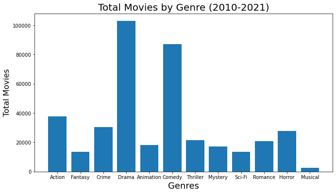

```python
# new range table
cut_table = full_table[full_table["releaseYear"] >2009]

genre_dict2 = defaultdict(int)

def get_genre (data):
  try:
    curr_genres = data.split(',')
    for genre in curr_genres:
      genre_dict2[genre] += 1
  except AttributeError:
    pass

  return data

cut_table['genres'].apply(get_genre)

del genre_dict2['War'],genre_dict2['Short'],genre_dict2['Biography']
del genre_dict2['History'],genre_dict2['Game-Show'],genre_dict2['Sport']
del genre_dict2['Reality-TV'],genre_dict2['News'],genre_dict2['Talk-Show']
del genre_dict2['Documentary'],genre_dict2['Music'],genre_dict2['Adventure']
del genre_dict2['Adult'],genre_dict2['Family'],genre_dict2['Western']

#Graph of total movies (2010-2021)
g = list(genre_dict2.keys())
vals = list(genre_dict2.values())

plt.figure(figsize=(11,6))
plt.bar(range(len(genre_dict2)),vals,tick_label=g)
plt.title('Total Movies by Genre (2010-2021)', fontsize=20)
plt.xlabel('Genres', fontsize=18)
plt.ylabel('Total Movies', fontsize=16)
plt.show()
```

We can observe that the trend has not changed. Comedy and Drama continue being the genres more produced. Lets look at the last 5 years total film production.

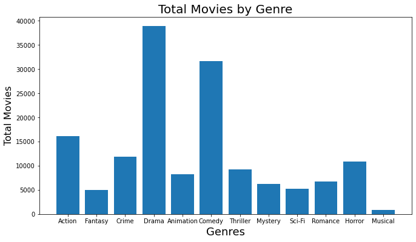

```python
#new range table
cut_table2 = full_table[full_table["releaseYear"] >2016]


genre_dict3 = defaultdict(int)

def get_genre (data):
  try:
    curr_genres = data.split(',')
    for genre in curr_genres:
      genre_dict3[genre] += 1
  except AttributeError:
    pass

  return data

cut_table2['genres'].apply(get_genre)

del genre_dict3['War'],genre_dict3['Short'],genre_dict3['Biography']
del genre_dict3['History'],genre_dict3['Game-Show'],genre_dict3['Sport']
del genre_dict3['Reality-TV'],genre_dict3['News'],genre_dict3['Talk-Show']
del genre_dict3['Documentary'],genre_dict3['Music'],genre_dict3['Adventure']
del genre_dict3['Adult'],genre_dict3['Family'],genre_dict3['Western']

#Graph of total movies 2010 by genre
g = list(genre_dict3.keys())
vals = list(genre_dict3.values())

plt.figure(figsize=(11,6))
plt.bar(range(len(genre_dict3)),vals,tick_label=g)
plt.title('Total Movies by Genre', fontsize=20)
plt.xlabel('Genres', fontsize=18)
plt.ylabel('Total Movies', fontsize=16)
plt.show()
```

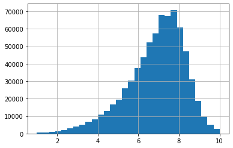

```python
full_table['averageRating'].hist(bins=30)
```

```python
period_table = full_table[full_table["releaseYear"] >2016]

period_table['Action'] = 0
period_table['Adventure'] = 0
period_table['Animation'] = 0
period_table['Comedy'] = 0
period_table['Drama'] = 0
period_table['Fantasy'] = 0
period_table['Horror'] = 0
period_table['Musical'] = 0
period_table['Romance'] = 0
period_table['Sci-Fi'] = 0
period_table['Thriller'] = 0

period_table.head()
```

[output not shown]

[output cut: 11 more lines]

[output not shown]

|  | tconst | title | releaseYear | genres | averageRating | numVotes | Action | Adventure | Animation | Comedy | Drama | Fantasy | Horror | Musical | Romance | Sci-Fi | Thriller |
| --- | --- | --- | --- | --- | --- | --- | --- | --- | --- | --- | --- | --- | --- | --- | --- | --- | --- |
| 1159570 | tt13026416 | Super Mario 3D World + Bowser's Fury | 2021 | Action,Adventure,Fantasy | 8.8 | 185 | 0 | 0 | 0 | 0 | 0 | 0 | 0 | 0 | 0 | 0 | 0 |
| 1286894 | tt14871658 | UFC 263: Adesanya vs. Vettori 2 | 2021 | Sport | 6.7 | 12 | 0 | 0 | 0 | 0 | 0 | 0 | 0 | 0 | 0 | 0 | 0 |
| 1287851 | tt14893986 | The Last of Us: Ellie's Revenge | 2021 | Action,Short | 8.8 | 6 | 0 | 0 | 0 | 0 | 0 | 0 | 0 | 0 | 0 | 0 | 0 |
| 1287850 | tt14893986 | The Last of Us: Ellie's Revenge | 2021 | Action,Short | 8.8 | 6 | 0 | 0 | 0 | 0 | 0 | 0 | 0 | 0 | 0 | 0 | 0 |
| 1190930 | tt13404978 | Head of the Snake | 2021 | Action,Crime,Drama | 8.8 | 299 | 0 | 0 | 0 | 0 | 0 | 0 | 0 | 0 | 0 | 0 | 0 |

```python
period_table = period_table.dropna()

i = 0

while i < len(period_table.index):
      curr_str = period_table.iat[i,3]
      if curr_str.find("Action") != -1:
        period_table.iat[i,6] = 1

      if curr_str.find("Adventure") != -1:
        period_table.iat[i,7] = 1

      if curr_str.find("Animation") != -1:
        period_table.iat[i,8] = 1

      if curr_str.find("Comedy") != -1:
        period_table.iat[i,9] = 1

      if curr_str.find("Drama") != -1:
        period_table.iat[i,10] = 1

      if curr_str.find("Fantasy") != -1:
        period_table.iat[i,11] = 1

      if curr_str.find("Horror") != -1:
        period_table.iat[i,12] = 1

      if curr_str.find("Musical") != -1:
        period_table.iat[i,13] = 1

      if curr_str.find("Romance") != -1:
        period_table.iat[i,14] = 1

      if curr_str.find("Sci-Fi") != -1:
        period_table.iat[i,15] = 1

      if curr_str.find("Thriller") != -1:
        period_table.iat[i,16] = 1

      i+=1

period_table.head()
```

|  | tconst | title | releaseYear | genres | averageRating | numVotes | Action | Adventure | Animation | Comedy | Drama | Fantasy | Horror | Musical | Romance | Sci-Fi | Thriller |
| --- | --- | --- | --- | --- | --- | --- | --- | --- | --- | --- | --- | --- | --- | --- | --- | --- | --- |
| 1159570 | tt13026416 | Super Mario 3D World + Bowser's Fury | 2021 | Action,Adventure,Fantasy | 8.8 | 185 | 1 | 1 | 0 | 0 | 0 | 1 | 0 | 0 | 0 | 0 | 0 |
| 1286894 | tt14871658 | UFC 263: Adesanya vs. Vettori 2 | 2021 | Sport | 6.7 | 12 | 0 | 0 | 0 | 0 | 0 | 0 | 0 | 0 | 0 | 0 | 0 |
| 1287851 | tt14893986 | The Last of Us: Ellie's Revenge | 2021 | Action,Short | 8.8 | 6 | 1 | 0 | 0 | 0 | 0 | 0 | 0 | 0 | 0 | 0 | 0 |
| 1287850 | tt14893986 | The Last of Us: Ellie's Revenge | 2021 | Action,Short | 8.8 | 6 | 1 | 0 | 0 | 0 | 0 | 0 | 0 | 0 | 0 | 0 | 0 |
| 1190930 | tt13404978 | Head of the Snake | 2021 | Action,Crime,Drama | 8.8 | 299 | 1 | 0 | 0 | 0 | 1 | 0 | 0 | 0 | 0 | 0 | 0 |

```python
top_genres = period_table.iloc[:, 6:-1].sum().sort_values(ascending=False).head(7).index.values
top_genres
```

```
array(['Drama', 'Comedy', 'Action', 'Horror', 'Adventure', 'Animation',
       'Romance'], dtype=object)
```

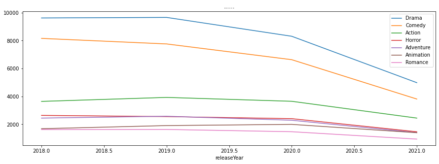

```python
period_table["releaseYear"].dropna()

genre_table = period_table.iloc[:, 6:].groupby(period_table["releaseYear"]).sum().loc["1960":"2021", top_genres]
genre_table.rolling(2).mean().plot(figsize=(15,5),title="......")
```

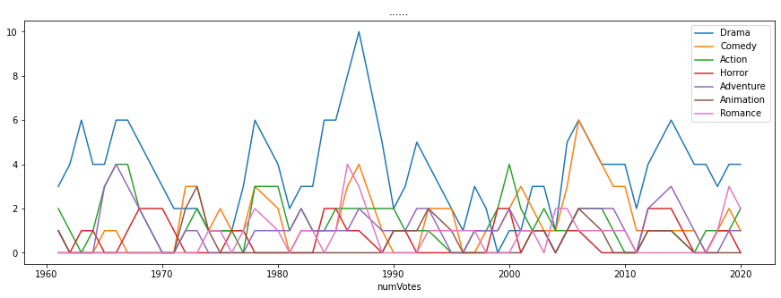

```python
genre_table = period_table.iloc[:, 6:].groupby(period_table["numVotes"]).sum().loc["1960":"2021", top_genres]
genre_table.rolling(2).mean().plot(figsize=(15,5),title="......")
```

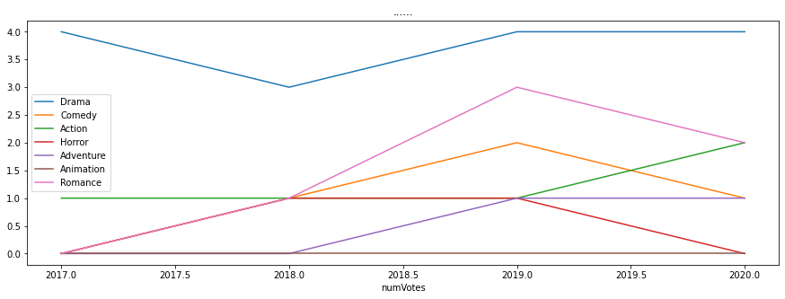

```python
genre_table = period_table.iloc[:, 6:].groupby(period_table["numVotes"]).sum().loc["2016":"2021", top_genres]
genre_table.rolling(2).mean().plot(figsize=(15,5),title="......")
```